# Regression Lab 1: Intro to R

Kareena del Rosario

2024-01-23

Our introduction to R will be divided into 3 different subsections (orienting yourself to R, data manipulation, data visualization)

```
Overview of Section 1

1. Different R Platforms
2. R Grammar
3. Installing and Loading Libraries
4. Using Functions
5. Importing datasets
```

# Level 1: Orienting yourself to R

## Different R Platforms: R Script, R Markdown, and Colab

#### R Script

This is the basic format for RStudio. The output goes to the console. Plots output to the window in the righthand corner. ‘#’ comments code.

#### R Markdown

Integrates R code with narrative text. Output and plots appear directly under the code. Can be “knitted” to output an easy-to-read Word, PDF, or HTML. Code is placed in separate blocks (shortcut: CMD + Option + i), which can be modified to skip the code or hide the code in the final output. Can create an outline using ‘#’ outside of the code blocks.

#### Google Colab

Functions like a Google Doc. Multiple users can access it at a time and does not require R to be installed.

## Understanding R Grammar

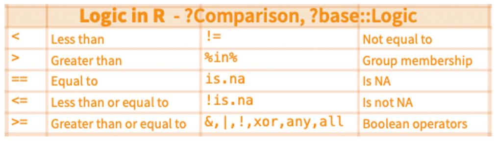

### == vs %in% vs =

```r
# these are vectors
# (basically, strings of values. always need to add 'c' if there is more than 1 value)
x <- c('a', 'b', 'c')
y <- c('c', 'b', 'a')
```

```
- What's up with the <-?
If you want to refer to something you created in R, whether that is a dataframe, vector, or whatever, you HAVE to save it to the environment (to the right) using "<-"
```

#### ==

```r
# logical operator: asks the program for a match
x == y
```

```
## [1] FALSE  TRUE FALSE
```

#### %in%

```r
# value matching: contains same variables
x %in% y
```

```
## [1] TRUE TRUE TRUE
```

```r
x %in% letters
```

```
## [1] TRUE TRUE TRUE
```

#### =

```r
# changes variables (new = old)
x = y

print(x)
```

```
## [1] "c" "b" "a"
```

```r
print(y)
```

```
## [1] "c" "b" "a"
```

### () vs []

#### Parentheses ()

```r
# parentheses are used for closing arguments
result = sum(1, 2, 3)
print(result)  # Outputs: 6
```

```
## [1] 6
```

#### Square brackets []

```r
# square brackets are used to specify what you want in a vector or dataframe

# for vectors
v = c(10, 20, 30, 40)
print(v[2])  # Accessing the second element, Outputs: 20
```

```
## [1] 20
```

```r
# Working with matrices or dataframes
m = matrix(1:9, nrow=3, ncol=3)
print(m)
```

```
##      [,1] [,2] [,3]
## [1,]    1    4    7
## [2,]    2    5    8
## [3,]    3    6    9
```

[row, column]

```r
print(m[2, 3])  # Accessing row 2, column 3
```

```
## [1] 8
```

```r
print(m[, 1])   # Accessing all rows in column 1
```

```
## [1] 1 2 3
```

## Installing Packages

```r
## Install Packages from CRAN
install.packages("dplyr")


## Install Package from GitHub
# install.packages("devtools")
library(devtools)

#devtools::install_github("DeveloperName/PackageName")
devtools::install_github("RandiLGarcia/dyadr")
```

## Loading Packages

```r
# Load Packages
library(dplyr)

# One Way to Load Multiple Packages
pkgs <- c("psych",
          "tidyr",
          "tidyverse",
          "dplyr",
          "haven",
          "lm.beta",
          "car",
          "skimr",
          "janitor",
          "labelled",
          "expss",
          "foreign")

lapply(pkgs, library, character.only = TRUE)
```

### Checking Packages

```r
search()
```

```
##  [1] ".GlobalEnv"        "package:foreign"   "package:expss"
##  [4] "package:maditr"    "package:labelled"  "package:janitor"
##  [7] "package:skimr"     "package:car"       "package:carData"
## [10] "package:lm.beta"   "package:haven"     "package:lubridate"
## [13] "package:forcats"   "package:stringr"   "package:purrr"
## [16] "package:readr"     "package:tibble"    "package:ggplot2"
## [19] "package:tidyverse" "package:tidyr"     "package:psych"
## [22] "package:dplyr"     "package:stats"     "package:graphics"
## [25] "package:grDevices" "package:utils"     "package:datasets"
## [28] "package:methods"   "Autoloads"         "package:base"
```

## Using Functions

In R, there are lots of ways you can do the same thing. One example is how to call a dataframe and the variables within it. We can either enter the dataframe name into each command or we can use dplyr’s pipe (this may depend on the package).

[figure not shown]

Here’s an example using R’s built in dataframe called ‘iris’:

```r
head(iris)
```

|  | Sepal.Length | Sepal.Width | Petal.Length | Petal.Width | Species |
| --- | --- | --- | --- | --- | --- |
| 1 | 5.1 | 3.5 | 1.4 | 0.2 | setosa |
| 2 | 4.9 | 3.0 | 1.4 | 0.2 | setosa |
| 3 | 4.7 | 3.2 | 1.3 | 0.2 | setosa |
| 4 | 4.6 | 3.1 | 1.5 | 0.2 | setosa |
| 5 | 5.0 | 3.6 | 1.4 | 0.2 | setosa |
| 6 | 5.4 | 3.9 | 1.7 | 0.4 | setosa |

In this exercise, we want to get the average Sepal.Length and Sepal.Width of the setosa species.

### Step-by-step approach

```
df$variable (specify dataframe and variable within the dataframe)
```

```r
# Call variable
iris$Species
```

```
##   [1] setosa     setosa     setosa     setosa     setosa     setosa
##   [7] setosa     setosa     setosa     setosa     setosa     setosa
##  [13] setosa     setosa     setosa     setosa     setosa     setosa
##  [19] setosa     setosa     setosa     setosa     setosa     setosa
##  [25] setosa     setosa     setosa     setosa     setosa     setosa
##  [31] setosa     setosa     setosa     setosa     setosa     setosa
##  [37] setosa     setosa     setosa     setosa     setosa     setosa
##  [43] setosa     setosa     setosa     setosa     setosa     setosa
##  [49] setosa     setosa     versicolor versicolor versicolor versicolor
##  [55] versicolor versicolor versicolor versicolor versicolor versicolor
##  [61] versicolor versicolor versicolor versicolor versicolor versicolor
##  [67] versicolor versicolor versicolor versicolor versicolor versicolor
##  [73] versicolor versicolor versicolor versicolor versicolor versicolor
##  [79] versicolor versicolor versicolor versicolor versicolor versicolor
##  [85] versicolor versicolor versicolor versicolor versicolor versicolor
##  [91] versicolor versicolor versicolor versicolor versicolor versicolor
##  [97] versicolor versicolor versicolor versicolor virginica  virginica
## [103] virginica  virginica  virginica  virginica  virginica  virginica
## [109] virginica  virginica  virginica  virginica  virginica  virginica
## [115] virginica  virginica  virginica  virginica  virginica  virginica
## [121] virginica  virginica  virginica  virginica  virginica  virginica
## [127] virginica  virginica  virginica  virginica  virginica  virginica
## [133] virginica  virginica  virginica  virginica  virginica  virginica
## [139] virginica  virginica  virginica  virginica  virginica  virginica
## [145] virginica  virginica  virginica  virginica  virginica  virginica
## Levels: setosa versicolor virginica
```

```r
# Filtering the data for species 'setosa'
filtered_data <- subset(iris, Species == "setosa")

# Selecting specific columns
selected_data <- filtered_data[,c("Sepal.Length", "Sepal.Width", "Species")]

# Grouping the data ('data of interest' ~grouped_by 'Species', the data, function)
final_result1 <- aggregate(cbind(Sepal.Length, Sepal.Width) ~ Species, selected_data, mean)

print(final_result1)
```

```
##   Species Sepal.Length Sepal.Width
## 1  setosa        5.006       3.428
```

### Dplyr approach

```
%>% (pipe data into functions; shortcut = CMD + Shift + M)
```

```r
library(dplyr)

final_result2 <- iris %>%
  filter(Species == "setosa") %>% # Filtering the data for species 'setosa'
  select(Sepal.Length, Sepal.Width, Species) %>% # Selecting specific columns
  group_by(Species) %>% # not necessary but guarantees it's kept in output
  dplyr::summarize(average_sepal_length = mean(Sepal.Length),
                   average_sepal_width = mean(Sepal.Width))

print(final_result2)
```

```
## # A tibble: 1 × 3
##   Species average_sepal_length average_sepal_width
##   <fct>                  <dbl>               <dbl>
## 1 setosa                  5.01                3.43
```

### Calling functions

```r
?mean
?dplyr::mutate
```

### Mini-challenge!

Let’s revisit () and [] using the vectors we created earlier:

```r
data <- data.frame(x, y)
as_tibble(data)
```

```r
new_data <- data [] # how would you subset COLUMN 2?
as_tibble(new_data)
```

```r
new_data2 <- data[] # how would you subset ROW 2?
as_tibble(new_data2)
```

## Importing Datasets

```r
## CSV
# Saved in the same folder
basic_df <- read.csv("depression_example_data.csv", stringsAsFactors = FALSE) # character strings will not be converted to factors
tibble_df <- read_csv("depression_example_data.csv") # reads as tibble

# Saved in different places
# Option 1 - Set working directory
getwd()
setwd("/Users/kareenadelrosario/Desktop/Local R Code/NewFolder")
read_csv("csvFileName.csv")

# Option 2 - Include file path
read_csv("/Users/kareenadelrosario/Desktop/Local R Code/NewFolder/csvFileName.csv")

# Option 3 - Choose file
read.csv(file.choose(), header = TRUE)

read_sav(file.choose()) # SPSS
read_sas(file.choose()) # SAS

# Option 4 - Use Menu
# file -> Import Dataset
```

## Exporting Datasets

```r
# base r
write.csv(data, "pathway")

# readr package has more export options and is slightly faster
write_csv(data, "pathway", na ="")

# haven packages allow you to export data as an SPSS or SAS file
write_sav()
write_sas()
```

### BONUS: Want to upload your R script to Colab? Make it a python file using the code below:

```r
# devtools::install_github("mkearney/rmd2jupyter")
library(rmd2jupyter)
rmd2jupyter("lab1_datamanivis_kdr.Rmd")
```